# Lesson 12: Inference for the Mean of Differences (Two Dependent Samples)

## Lesson Outcomes

Show/Hide Outcomes

## Introduction to Paired Data

It is very common for researchers to conduct studies in which they administer a pre-test to a group of individuals, provide some treatment to those individuals, and then give a post-test to each individual. Since each individual in the study has both a pre-test and post-test measurement, researchers can use the difference between the post- and pre-test measurements as a measure of the effect the treatment had on each particular individual. The average of these differences can also be computed to find the average effect the treatment had on indvidiuals. We call this the *mean of the differences* for paired data.

These study designs are also called a **matched-pairs** design or we say we have **dependent samples**. Matched-pairs (or **paired-data**) designs typically involve only one population, and a pair of observations is drawn on the individuals selected for the sample (i.e., there are two measurements per individual). If an individual is selected to participate in the pre-test (i.e., they are selected to be part of group 1), they are automatically selected to participate in the post-test (i.e., they are chosen to be in group 2 automatically.)

A hypothesis test for two means with paired data (dependent samples) is conducted in the same way as a hypothesis test for a single mean with $\sigma$ unknown, the one-sample t test. The only exception is that the pairs of data must be subtracted before you start any computations. From a practical perspective, after you compute the differences for each matched pair, then you apply the one-sample procedures you have already learned to those differences.

We will first explore an application of pre- and post-testing in a weight loss study.

## Hypothesis Tests

### Mahon’s Weight Loss Study

**Background**

Annie Mahon and other researchers in Wayne Campbell’s nutrition lab studied the weight loss of $n = 27$ middle aged women who consumed a prescribed low-calorie diet. The women’s weights were recorded (in kilograms) at the beginning of the study and after the nine-week diet period. The data are given in the file weight_loss.xlsx. An excerpt of the data is shown below.

| Subject | Pre Weight (kg) | Post Weight (kg) |
| --- | --- | --- |
| 1 | 62.5 | 56.1 |
| 2 | 88.8 | 80.2 |
| 3 | 74.7 | 70.8 |
| $\vdots$ | $\vdots$ | $\vdots$ |
| 26 | 76.3 | 73.8 |
| 27 | 82.1 | 77.9 |

Notice the structure of the data. The weight of each subject was measured before the study and at the conclusion of the study. Each person provided a pre-study weight and a post-study weight. Stated differently, the pre-study weights and the post-study weights are paired. For each row of data, both of these numbers came from the same person. When we collect two observations of the same measurement on each subject, we call it **paired data**. Sometimes paired data are called **dependent samples**.

Answer the following question:

1. The researchers measured the initial weights of the women prior to the study, even though they were not particularly interested in this value. What was the purpose of measuring the pre-study weights?

Show/Hide Solution

### R Instructions for Computing Paired Differences

The researchers are not interested in the weights of the women, they are more interested in the *change* in the women’s weights. This will give them a measure of the effectiveness of the low-calorie diet. In other words, they are interested in the difference of the weights after the study compared with before:
$$\text{Difference} = \text{Post Weight} - \text{Pre Weight}$$

We can calculate the difference (or change) in weight for each woman in the study:

| Subject | Post Weight (kg) | Pre Weight (kg) | Difference in Weight (kg) |
| --- | --- | --- | --- |
| 1 | 56.1 | 62.5 | 56.1 $-$ 62.5 = -6.4 |
| 2 | 80.2 | 88.8 | 80.2 $-$ 88.8 = -8.6 |
| 3 | 70.8 | 74.7 | 70.8 $-$ 74.7 = -3.9 |
| $\vdots$ | $\vdots$ | $\vdots$ | $\vdots$ |
| 26 | 73.8 | 76.3 | 73.8 $-$ 76.3 = -2.5 |
| 27 | 77.9 | 82.1 | 77.9 $-$ 82.1 = -4.2 |

R Instructions

To compute the *differences* within each paired set of measurements in R, begin by reading in the weight_loss.xlsx data into RStudio. (If you need a reminder on how to read in data, click here.)

Then, calculate the *differences* using the assignment operator `<-` and the selection operator `$`:

```r
weight_loss$difference <- weight_loss$post - weight_loss$pre
```

Here we chose the order Post - Pre so that a positive difference would show an increase in weight (kg) from Pre-Weight to Post-Weight and a negative difference would show a decrease in weight (kg) from Pre-Weight to Post-Weight. Thus, a negative difference means the woman lost weight. This is usually the preferred order of subtraction with “Post vs. Pre” studies.

Once the differences are computed, we can compute the mean, median, standard deviation and so on using codes like the following.

```r
library(mosaic)
favstats(weight_loss$difference)
```

```
##    min   Q1 median   Q3  max      mean       sd  n missing
##  -13.6 -8.9   -6.7 -4.2 -1.6 -6.803704 3.172051 27       0
```

So we find that

$$\bar{d} = -6.804 \\
s_d = 3.172 \\
n = 27$$

Notice that we use $\bar d$ to represent the mean of the difference where $d = post-pre$. We use a subscript of $d$ to indicate that the standard deviation we computed is the standard deviation of the differences.

We make a histogram and boxplot of the differences:

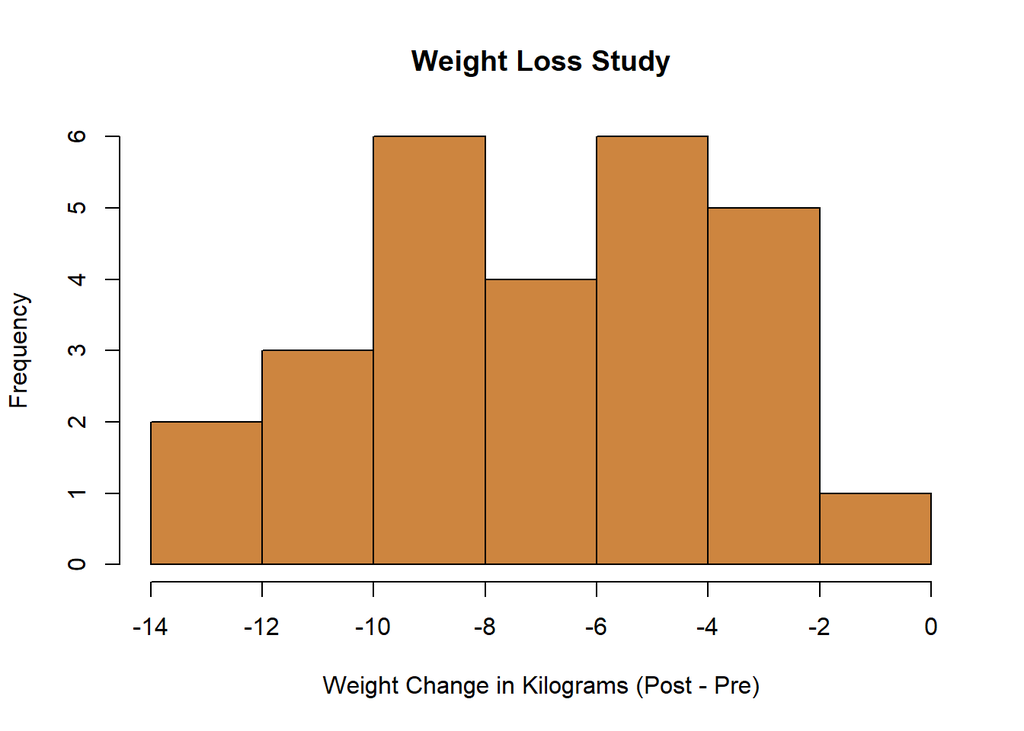

```r
hist(weight_loss$difference,
     col = "tan3",
     xlab = "Weight Change in Kilograms (Post - Pre)",
     main = "Weight Loss Study")
```

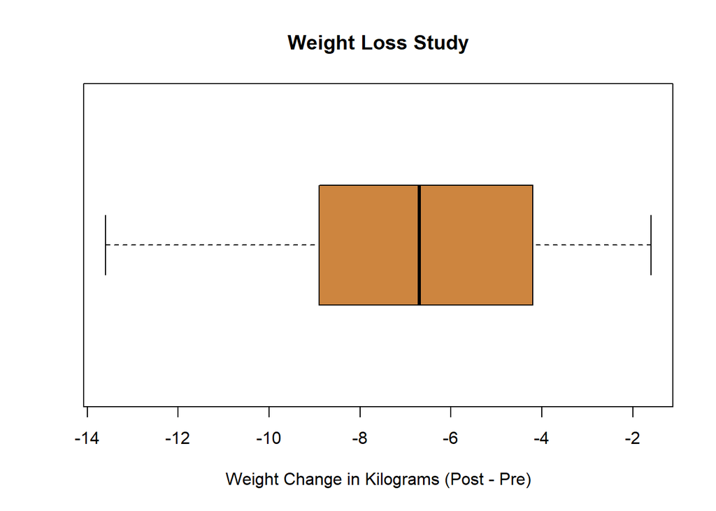

```r
boxplot(weight_loss$difference,
        horizontal=TRUE,
        col = "tan3",
        xlab = "Weight Change in Kilograms (Post - Pre)",
        main = "Weight Loss Study")
```

Answer the following questions:

2. What is the difference in the post- and pre-study weights for the first person included in the data file?

Show/Hide Solution

3. What is the mean of the *differences*? Said differently, what is the mean change in the weights of the women who participated in the study?

Show/Hide Solution

4. Interpret the value you calculated in Question 3.

Show/Hide Solution

**Relationship to a One Sample t-test**

After you have subtracted the pre-study weights from the post-study weights, you are left with a column of differences. We will denote the pre-study weights by $x_1$ and the post-study weights by $x_2$. Then, the differences can be denoted as $d = x_2 - x_1$. The difference, $d$, is defined as the change in the volunteer’s weight during the study.

After computing the differences, we do not use the data for the individual groups anymore. The researchers are not interested in the values of the women’s weights at the beginning of the study or at the end of the study. They are interested in the difference in the weights after the participants complete the study.

After we subtract, we can conduct a hypothesis test to determine if the mean of the differences is less than zero. We use the symbol $\mu_d$ to represent the true mean difference in the weights of women who follow the diet prescribed in this study. The null hypotheses is that the true mean difference is zero ($\mu_d = 0$). In other words, the null hypothesis states that the prescribed diet does not influence the weights of women. The alternative hypothesis is that there is a decrease in the weights of the women, in other words, that the true mean difference is less than zero ($\mu_d < 0$).

Notice that this is essentially a one-sample t-test where the data are the *differences in the women’s weights*. We have one column of data, the differences. We are testing whether the true mean difference is less than zero (or not equal to zero, or greater than zero). So, a test for the *differences of matched pairs* with dependent samples is just like a test for one mean with $\sigma$ unknown.

In the hypothesis test, we will refer to the variable representing the differences as $d$. We will use this notation throughout the hypothesis test. For example, the true population mean will be labeled $\mu_d$ and the sample mean will be labeled $\bar d$. The sample standard deviation of the differences is denoted $s_d$.

### Hypothesis Test for Mahon’s Weight Loss Data

**Summarize the relevant background information**

Twenty-seven women participated in a nine week weight loss study. During the study period, the participants were provided a reduced calorie diet. Their weights in kilograms were recorded at the beginning of the study and nine weeks later. The difference of the weights is defined as the post-study weights minus the pre-study weights. The researchers expected that the mean difference in the weights would be negative–in other words, that the women would tend to lose weight.

**State the null and alternative hypotheses and the level of significance**

$$\begin{align}
H_0: &~~ \mu_d = 0 \\
H_a: &~~ \mu_d < 0
\end{align}$$

We will use the $\alpha = 0.05$ level of significance.

**Describe the data collection procedures**

The women’s weights were recorded at the beginning of the study. The women were provided a reduced calorie diet for nine weeks. Then, their weights were measured again at the end of the study. A calibrated scale was used to provide an accurate weight.

**Give the relevant summary statistics**

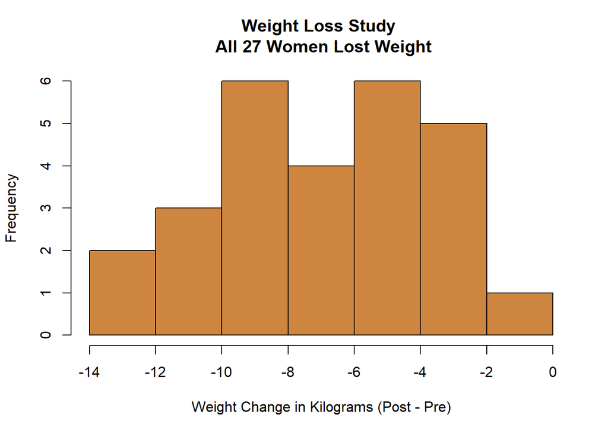

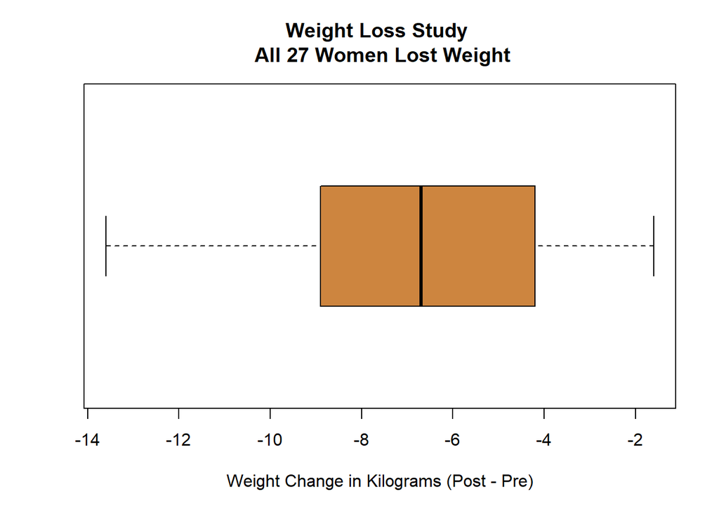

From the R output demonstrated previously, we can see a histogram of the data and get the following numerical summaries:

$$\begin{align}
\bar d & = -6.804 \\
s_d & = 3.172 \\
n & = 27
\end{align}$$

**Verify the requirements have been met**

Like the one-sample t-test, this procedure is robust, meaning that it is not very sensitive to the requirements. If they are only mildly violated, the test will still give reasonably good results.

The requirements for this procedure are the same as the requirements for a one-sample t-test:

- **the data represent a simple random sample from the population**

  The subjects were recruited via advertisements for a research study. The participants volunteered to participate. It is not a simple random sample of all middle-aged women, so there could be some selection bias of the sample that would invalidate the results, but there is nothing obvious about how the participants were selected to immediately invalidate the results.

  From a practical perspective, it is impossible to get a simple random sample of people in the general population. When research trials are conducted, people must volunteer to participate. This can lead to a selection bias, but is the accepted practice.
- **the mean of the differences $\bar{d}$ follows a normal distribution**

  We will assume the requirement of normality of $\bar{d}$ is satisfied for Mahon’s data. Though the sample size (n = 27) is not quite up to 30, the histogram of differences looks fairly normal, so $\bar d$ will be approximately normal and the requirement is satisfied. If the data had been highly skewed, or there was a more pronounced bimodal pattern in the histogram, then we would be worried about the results of the test and would have recommended they redo the study with a larger sample size in order to have confidence in the results of the t-test.

**Give the test statistic and its value**

### R Instructions for a Paired Samples t Test

R Instructions

To perform a paired samples t test in R, first compute the *differences* within each paired set of measurements in R as was shown previously.

Then, run a t test on the differences. Since the null hypothesis for the Mahon Weight Loss study was $H_0: \mu_d = 0$, we use `t.test(..., mu = 0)`. Since the alternative hypothesis was that $H_a: \mu_d < 0$, we use the code `t.test(..., alternative = "less")`. Putting this all together we have the following.

```r
t.test(weight_loss$difference,
       mu = 0,
       alternative = "less",
       conf.level = 0.95)
```

```
    One Sample t-test

data:  weight_loss$difference
t = -11.145, df = 26, p-value = 1.059e-11
alternative hypothesis: true mean is less than 0
95 percent confidence interval:
     -Inf -5.76249
sample estimates:
mean of x
-6.803704
```

The test statistic for a test involving paired data when $\sigma$ is unknown is a $t$. For this situation, the value is:
$$t = \frac{-6.804 - 0}{3.17/\sqrt{27}} = -11.145$$
See that this calculation matches the test statistic given in the R output. The degrees of freedom and p-value can also be found in the R output.

**State the degrees of freedom**

The degrees of freedom are one less than the sample size. They are also shown automatically in the output of the test results.

$$df = n - 1 = 27 - 1 = 26$$

**Find the $P$-value and compare it to the level of significance**

$$P\text{-value} = 1.059 \times 10^{-11} < 0.05 = \alpha$$

**State your decision**

Since the $P$-value is less than the level of significance, we reject the null hypothesis.

**Present your conclusion in an English sentence, relating the result to the context of the problem**

There is sufficient evidence to suggest that the reduced calorie diet used in this study results in weight loss for middle-aged women with the average weight loss around 6.804 kg.

### Nosocomial Infections

**Summarize the relevant background information**

Matched-pairs designs are not just used in pre- and post-test situations. They are also used in situations where it is not possible to randomly assign subjects to treatment groups because of ethical reasons. For example, nosocomial (pronounced: NO-suh-KOH-MEE-uhl) infections are infections that occur in hospitals, but are not a result of the original condition. An example of a nosocomial infection is when a heart attack patient develops a staph infection at the site of an IV injection. The infection was not caused by the heart attack, but it was acquired in the hospital. Nosocomial infections are very dangerous and may result in longer recovery times or increased death rates.

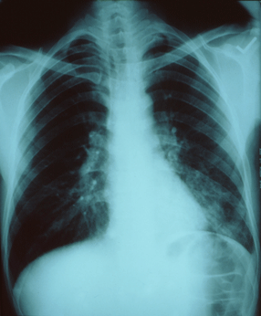

Health care providers suspect that nosocomial infections increase the amount of time required to recover from an illness or injury. In controlled experiments, subjects (e.g., patients) are randomly assigned to treatments. However, it is not ethical to give patients a nosocomial infection in order to determine if it increases the duration of their hospital stay! At best, we can collect information on the duration of hospital stays for patients who acquire nosocomial infections and compare them to the duration of the stays for patients who do not.

There are many factors that affect the amount of time that a patient will need to stay in the hospital, including: nature of illness, types of procedures conducted, overall health, gender, age, etc. How can health care practitioners assess the effect of a nosocomial infection in the presence of so many other variables?

One way is to match a patient who develops a nosocomial infection with another one who has similar characteristics (illness, procedures, health, gender, age group, etc.) but does not develop a nosocomial infection. Now, the patients are matched into pairs with similar characteristics, where the principle difference between the members of each pair is whether or not they acquired a nosocomial infection.

By pairing the patients according to specific characteristics, the researchers can now subtract to observe a difference in their recovery times. In this way, it is possible to assess if nosocomial infections increase the mean duration of a hospital stay. Some researchers conducted such a study in which 52 pairs of patients were matched based on clinical characteristics. A patient with a nosocomial infection was matched as closely as possible to a similar case where there was no nosocomial infection. Patients who died were excluded from the study . The lengths of the hospital stays (in days) for these patients are given in the file hospital_infections.xlsx.

The difference, $d$, is defined as the duration of the hospital stay of the individual in the pair with the nosocomial infection minus the duration of the stay for the individual who did not get a nosocomial infection:
$$difference = infected - not_infected$$
After computing the differences, we do not use the data for the individual groups anymore. In fact, after we subtract, the hypothesis test is conducted (essentially) like a one-sample test for a single mean with $\sigma$ unknown.

Answer the following questions:

5. **State the null and alternative hypotheses and the level of significance**

Show/Hide Solution

In order to get the correct $P$-value, we need to indicate the proper alternative hypothesis in the `t.test(..., altnerative = "greater")`.

Answer the following questions:

6. **Describe the data collection procedures**

Show/Hide Solution

Answer the following questions:

7. **Give the relevant summary statistics**

Show/Hide Solution

8. **Make an appropriate graph to illustrate the data**

Show/Hide Solution

Answer the following questions:

9. **Verify the requirements have been met**

Show/Hide Solution

10. **Give the test statistic and its value**

Show/Hide Solution

11. **State the degrees of freedom**

Show/Hide Solution

13. **Find the $P$-value and compare it to the level of significance**

Show/Hide Solution

14. **State your decision**

Show/Hide Solution

Answer the following questions:

15. **Present your conclusion in an English sentence, relating the result to the context of the problem**

Show/Hide Solution

### Additional Worked Examples

Viewing additional examples can help your understanding. Click on the link below to see two more examples of hypothesis tests.

Show/Hide Additional Examples

## Confidence Intervals

We can compute a confidence interval for the true mean of the differences for paired data. After the differences between two paired data sets have been calculated, we can create a confidence interval for the true mean of the differences. To do this, we follow the instructions for creating a confidence interval for a one mean with $\sigma$ unknown, but we use the column of differences as the data set.

The requirements for creating a confidence interval for the difference of means are the same as the requirements for the hypothesis test. We require that:

- A simple random sample was drawn from the population
- The mean of the differences is normally distributed

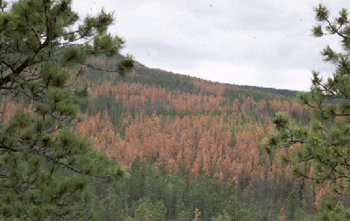

### Mountain Pine Beetle Attacks

**Summarize the relevant background information**

Mountain pine beetles are small insects that bore into the bark of trees. The female beetles that first infest the tree emit pheromones to attract other beetles. In response to the pheromones, many beetles bore into the tree and ultimately kill it. The insects can destroy large tree stands within one year.

Lodgepole pine (*Pinus contorta* Dougl.ex Loud.) are particularly susceptible to mountain pine beetle (*Dendroctonus ponderosae* Hopkins) outbreaks. The image above shows the destruction that can be caused by these insects. The large brown patches are pines that have been killed by the beetles.

Answer the following questions:

37. The mountain pine beetle threatens many forests in the United States. These tiny insects are only 0.5 cm long–about the size of a grain of rice. This photo of a mountain pine beetle is magnified greatly. These little creatures can destroy a large, healthy forest. Can you think of a spiritual parallel?

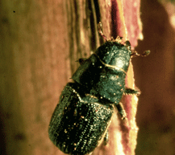

Show/Hide Solution

**Describe the data collection procedures**

In a study conducted in the Arapaho National Forest in Colorado, researchers from the USDA Forest Service studied the effect of pine beetle outbreaks on the average number of trees in an area. The researchers counted the number of established trees per hectare before a pine beetle outbreak and seven years after an outbreak. (One hectare is an area of 100 meters by 100 meters.) Data representative of their observations are given in the file pine_beetle.xlsx.

Answer the following questions:

**Give the relevant summary statistics**

38. Find the mean and standard deviation of the number of trees per hectare *before* the pine beetle outbreak. How would you describe the density of the trees in this forest? Express this in terms that make sense to you.

Show/Hide Solution

39. Repeat question 38 for the number of trees per hectare *after* the outbreak.

Show/Hide Solution

40. Find the differences by subtracting the “before” counts from the “after” counts:

$$difference = after - before$$
**Be careful to match the order of subtraction.**

- For these differences, report the mean, the standard deviation, and the sample size.

Show/Hide Solution

**Make an appropriate graph to illustrate the data**

41. Create a histogram and boxplot of the differences in the density of the trees.

Show/Hide Solution

To create a confidence interval for the true mean of the differences $\mu_d$ in R, use the following.

### R Instructions for Confidence Intervals

R Instructions

**To calculate confidence intervals for the true mean of the difference in R, do the following**:

- Read in the data to RStudio if you haven’t already: pine_beetle
- Compute the differences if you haven’t already:

```r
pine_beetle$difference <- pine_beetle$after - pine_beetle$before
```

- Use the code `t.test(pine_beetle$difference, conf.level = 0.95)` to set the desired confidence level and create the confidence interval.

```r
t.test(pine_beetle$difference, conf.level = 0.95)
```

```
    One Sample t-test

data:  pine_beetle$difference
t = -332.43, df = 169, p-value < 2.2e-16
alternative hypothesis: true mean is not equal to 0
95 percent confidence interval:
 -438.1211 -432.9483
sample estimates:
mean of x
-435.5347
```

The row of the output shown above called “95 percent confidence interval:” shows the **lower bound** as -438.1211 and the **upper bound** as -432.9483.

Answer the following questions:

42. **Verify the requirements have been met.**

Show/Hide Solution

43. **Find the confidence interval**. Use the 95% level of confidence.

Show/Hide Solution

**Present your observations in an English sentence, relating the result to the context of the problem**

Interpret the confidence interval we created. We are 95% confident that the true mean change in the number of trees per hectare after a pine beetle outbreak is between $-438.121$ and $-432.948$ trees per hectare. Stated differently, we are 95% confident that the true mean *decrease* in the number of trees per hectare after a pine beetle outbreak is between $432.948$ and $438.121$ trees per hectare.

### Sleep-Inducing Drugs

In this example, we explore how to handle missing values in the data.

**Summarize the relevant background information**

In William Sealy Gosset’s landmark paper on the $t$-distribution, he cites data on a sleep-inducing drug. In a paper published in 1905, Arthur R. Cushny and A. Roy Peebles reported the effect of Laevorotatory Hyoscyamine Hydrobromate (L-Hyoscyamine) on the length of time that people sleep before waking. The primary research question is: does L-Hyoscyamine impact the mean amount of time that people sleep? We will compute a 90% confidence for the true mean difference in the times.

**Describe the data collection procedures**

Eleven subjects were included in the study. At the start of the study, the researchers observed the average length of time that each of the participants slept before waking. Later, each subject was given 0.6 mg of L-Hyoscyamine and the duration of uninterrupted sleep was again measured.

The difference in the amount of time each person slept was computed by subtracting the amount of time the subjects slept when taking the drug minus the sleep duration with no drug. The data are given in the file sleep.xlsx. After reading in these data, run the following to compute the column of differences:

```r
sleep$difference = sleep$treatment - sleep$control
```

Run the command `View(sleep)` to examine the data file.

Notice that the “control” data for Subject #11 is missing. It is not possible to compute a difference for this person, so their data will be omitted from our analysis. For this analysis, we will use the remaining $n = 10$ observations.

Answer the following questions:

**Give the relevant summary statistics**

44. Report the mean, standard deviation, and sample size for the differences.

Show/Hide Solution

**Make an appropriate graph to illustrate the data**

45. Create a graph of the differences in the hours of sleep.

Show/Hide Solution

Answer the following questions:

46. **Verify the requirements have been met.**

Show/Hide Solution

47. **Find the confidence interval**. Use the 90% level of confidence.

Show/Hide Solution

Answer the following questions:

48. **Present your observations in an English sentence, relating the result to the context of the problem**

Show/Hide Solution

## Summary

Remember…

- The key characteristic of **dependent samples** (or **matched pairs**) is that knowing which subjects will be in group 1 determines which subjects will be in group 2.
- We use slightly different symbols when conducting inference using dependent samples:

| Symbol | Explanation |
| --- | --- |
| $x_1$ | Group 1 Values |
| $x_2$ | Group 2 Values |
| $d = x_2 - x_1$ | Differences |
| $\bar{d}$ | Sample Mean of the Differences |
| $\mu_d$ | True Population Mean of the Differences |
| $s_d$ | Sample Standard Deviation of the Differences |

- When conducting hypothesis tests using dependent samples, the null hypothesis is always $\mu_d = 0$, indicating that there is no change between the first population and the second population. The alternative hypothesis can be left-tailed ($<$), right-tailed($>$), or two-tailed($\ne$).
- The R code to perform a paired samples t test requires two steps. First, the `differences` must be computed. Second, the `t.test(sleep$difference, mu = 0, alternative = "two.sided")` should be used. Be sure to match the `alternative =` statement to either `"less"`, `"greater"`, or `"two.sided"` so that it matches whatever is stated in the actual $H_a$ statement.
- The R code to created a confidence interval for the true mean of the differences, $\mu_d$, uses `t.test(sleep$difference, conf.level = 0.95)` where `conf.level =` can be changed to either 0.9 (for a 90% confidence interval) or 0.99 (for a 99% confidence interval).

## Navigation

| **Previous Reading** | **This Reading** | **Next Reading** |
| --- | --- | --- |
| Lesson 11: Inference for One Mean: Sigma Unknown | Lesson 12: Inference for Two Means: Paired Data | Lesson 13: Inference for Two Means: Independent Samples |